# CQF M3 Zhebin_WU_v2

```python
import random
import pandas as pd
import numpy as np
import scipy
from scipy import stats
from scipy.stats import norm
from scipy.optimize import minimize
from numpy import math
import matplotlib.pyplot as plt
from mpl_toolkits import mplot3d
from matplotlib import cm
import cufflinks as cf
cf.set_config_file(offline=True)
```

```python
# time
def time(T,timesteps):
    t = np.linspace(0.001,T,timesteps)
    return t
```

## Euler-Maruyama Method for simulation

**geometric Brownian motion** $S$ for stock price , $r$ for the constant risk-free rate, $\sigma$ for volatility, $W$ for Brownian motion and $\phi$ for *standard normal pdf*. $$dS = rSdt + σSdW(t)$$

**Euler-Maruyama** $$\delta S = r S \delta t + \sigma S \sqrt{\sigma t}\phi$$

$$S_{t+\delta t} = S_{t}(1+r\delta t + \sigma \phi\sqrt{\delta t})$$

**Euler discretization of SDE**: $$S_{t} = S_{t-{\delta}t} exp^{[(r-\frac{1}2{\sigma}^2){\delta}t +{\sigma}\phi{\sqrt{\delta}t}]}$$

Simulate the underlying asset using *Euler-Maruyama*:

```python
def geometricpath(mu,sigma2,timesteps,T,S0,sims):
    t=time(T,timesteps)
    path=np.zeros((len(t),sims))
    path[0]=S0
    random.seed(10000)
    for x in range(1,len(t)):
        delta_t=t[x]-t[x-1]
        z=np.random.standard_normal(sims)
        path[x]=path[x-1]*np.exp((mu-sigma2/2)*delta_t+((sigma2*delta_t)**0.5)*z)
    return path

price_path=geometricpath(0.05,0.2,252,1,100,10000)
print(pd.DataFrame(price_path))
```

```
           0           1           2           3           4           5     \
0    100.000000  100.000000  100.000000  100.000000  100.000000  100.000000
1    100.631418   98.097768   96.562979  100.750177  100.689231   99.586745
2    103.710306   99.407062   92.906893  100.343172   99.984450  104.882338
3    103.523347  100.077808   91.541504  101.327382  104.690538  108.784928
4    106.382297  100.752884   93.676926   99.992207  105.588636  116.123816
..          ...         ...         ...         ...         ...         ...
247   91.619243   82.578458  149.311858   76.590442  141.438461  185.436885
248   90.906882   81.679931  145.886608   76.223087  141.681418  185.859695
249   90.030436   80.047391  138.364710   73.051118  142.814475  191.268916
250   91.442501   81.891887  137.887854   74.473195  143.093789  189.611134
251   91.975735   81.127254  135.455881   71.622347  143.143618  187.100729

           6           7           8           9     ...        9990  \
0    100.000000  100.000000  100.000000  100.000000  ...  100.000000
```

[output cut: 38 more lines]

```python
pd.DataFrame(price_path).iloc[:,:100].iplot(title='Simulated Geometric Brownian Motion Paths', xTitle='Time Steps', yTitle='Index Levels')
```

[interactive chart not shown]

## Asian options

$C$ for call options, $P$ for put options, $\mathbb{Q}$ for risk neutral measure, $K$ for strike price, $S_T$ for stock price at expiry, $\bar{S}$ for the average of stock prices

**Payoff of fixed strike Asian options**: $$C_{T} = max (0, \bar{S} - K)$$ $$P_{T} = max (0, K - \bar{S})$$

**Price of fixed strike Asian options**. $$C= e^{−r(T−t)}(E^\mathbb{Q}[max (0,\bar{S}-K)])$$ $$P= e^{−r(T−t)}(E^\mathbb{Q}[max (0,K-\bar{S})])$$

**Payoff of fixed price Asian options**: $$C_{T} = max (0, S_{T} -\bar{S})$$ $$P_{T} = max (0, \bar{S} - S_{T})$$

**Parice of fixed stock price Asian options**. $$C= e^{−r(T−t)}(E^\mathbb{Q}[max (0,S_{T} -\bar{S}])$$ $$P= e^{−r(T−t)}(E^\mathbb{Q}[max (0,\bar{S} - S_T])$$

More commonly, for practical and legal reasons, when pricing Asian options, the data is usually sampled **discretely**.

For the sake of simplicity, we set $t=0$ when computing the expected value of the discounted payoff under the risk-neutral measure $\mathbb{Q}$.

**Discrete arithmetic average**: $$\sum_{i=1}^{n}\frac{1}{n}S(t_i)$$

**Discrete geometric mean**: $$\mathcal{G}=[\prod_{i=1}^{n}S(t_i)]^\frac{1}{n}$$ $$=e^{\frac{1}{n}\sum_{i=1}^{n}lnS(t_i)}$$

To derive the price of Asian option at different circumstances, we need the following user-defined functions:

```python
# Arithmetic Asian option with fixed strike
def A_asian_option_fs(K,r,T,price_path):
    Avg_a = price_path.mean(axis=0) # arithmetic mean of stock prices
    C0 = np.exp(-r*T) * np.mean(np.maximum(Avg_a - K, 0)) # discounted expected payoff of Asian call
    P0 = np.exp(-r*T) * np.mean(np.maximum(K - Avg_a, 0)) # discounted expected payoff of Asian put
    return C0,P0
C_0,P_0=A_asian_option_fs(100,0.05,1,price_path)

# Arithmetic Asian option with fixed price
def A_asian_option_fp(r,T,price_path):
    Avg_a = price_path.mean(axis=0)
    S_T = pd.Series(pd.DataFrame(price_path).iloc[-1,:]) # fixed price at expiry
    C0 = np.exp(-r*T) * np.mean(np.maximum(S_T- Avg_a, 0)) # discounted expected payoff of Asian call
    P0 = np.exp(-r*T) * np.mean(np.maximum(Avg_a - S_T, 0)) # discounted expected payoff of Asian call
    return C0,P0
C_1,P_1=A_asian_option_fp(0.05,1,price_path)

print(f'Arithmetic Asian Call Option( with fixed strike) Price: {C_0:0.4f}')
print(f'Arithmetic Asian Put Option( with fixed strike) Price: {P_0:0.4f}')
print(f'Arithmetic Asian Call Option( with fixed price) Price: {C_1:0.4f}')
print(f'Arithmetic Asian Put Option( with fixed price) Price: {P_1:0.4f}')
```

```
Arithmetic Asian Call Option( with fixed strike) Price: 10.9817
Arithmetic Asian Put Option( with fixed strike) Price: 8.5961
Arithmetic Asian Call Option( with fixed price) Price: 11.2851
Arithmetic Asian Put Option( with fixed price) Price: 8.7606
```

```python
# Set parameters
E = 100 # strike price
r = 0.05
T = 1

# Geometric Asian option with fixed strike
def G_asian_option_fs(K,r,T,price_path):
    Avg_g = np.exp(np.log(price_path).mean(axis=0)) # geometric mean of stock prices
    C0 = np.exp(-r*T) * np.mean(np.maximum(Avg_g - K, 0)) # discounted expected payoff of Asian call
    P0 = np.exp(-r*T) * np.mean(np.maximum(K - Avg_g, 0)) # discounted expected payoff of Asian put
    return C0,P0
C_fs,P_fs=G_asian_option_fs(E,r,T,price_path)

# Geometirc Asian option with fixed price
def G_asian_option_fp(r,T,price_path):
    Avg_g = np.exp(np.log(price_path).mean(axis=0))
    S_T = pd.Series(pd.DataFrame(price_path).iloc[-1,:]) # fixed price at expiry
    C0 = np.exp(-r*T) * np.mean(np.maximum(S_T- Avg_g, 0)) # discounted expected payoff of Asian call
    P0 = np.exp(-r*T) * np.mean(np.maximum(Avg_g - S_T, 0)) # discounted expected payoff of Asian call
    return C0,P0
C_fp,P_fp=G_asian_option_fp(r,T,price_path)

print(f'Geometric Asian Call Option( with fixed strike) Price: {C_fs:0.4f}')
print(f'Geometric Asian Put Option( with fixed strike) Price: {P_fs:0.4f}')
print(f'Geometric Asian Call Option( with fixed price) Price: {C_fp:0.4f}')
print(f'Geometric Asian Put Option( with fixed price) Price: {P_fp:0.4f}')
```

```
Geometric Asian Call Option( with fixed strike) Price: 10.0309
Geometric Asian Put Option( with fixed strike) Price: 9.2627
Geometric Asian Call Option( with fixed price) Price: 12.1566
Geometric Asian Put Option( with fixed price) Price: 8.0149
```

## Vary the data

Within the following cells I varied **risk-free rate** and **volatility**, then I ploted 3-D figures as examples to show the affects of the variation of risk-free rate and volatility on option prices.

```python
# Arithmetic fixed strike Asian Call Option
mu_v=np.linspace(0.01,0.1,25)
sigma2_v=np.linspace(0.01,0.9,25)
sims=500
S0=100
K=100
result=np.zeros([len(mu_v),len(sigma2_v)])
random_vector=np.zeros(sims*3)
for n in range(0,len(random_vector)):
    random_vector[n]=random.gauss(0,1)
for x in range(0,len(mu_v)):
    drift=mu_v[x]
    for y in range(0,len(sigma2_v)):
        vol=sigma2_v[y]
        sample_payoff=np.zeros(sims)
        for n in range(0,sims):
            S1=S0*np.exp((drift-vol/2)*1/3+((vol*1/3)**0.5)*random_vector[n]) # dt=1/3
            S2=S1*np.exp((drift-vol/2)*1/3+((vol*1/3)**0.5)*random_vector[n+1])
            S3=S2*np.exp((drift-vol/2)*1/3+((vol*1/3)**0.5)*random_vector[n+2])
            M = np.mean(np.array([S1,S2,S3]))
            sample_payoff[n]=max(M-K,0) # Arithmetic fixed strike Asian payoff
        result[x,y]=np.mean(sample_payoff)*np.exp(-drift) # option price
def f(mu,sigma2):
    for a in range(0,len(mu_v)):
        if mu_v[a]==mu:
            x = a
            break
    for b in range(0,len(sigma2_v)):
        if sigma2_v[b]==sigma2:
            y = b
            break
    return(result[x,y])
mu = mu_v
sigma2=sigma2_v
MU,SIGMA2=np.meshgrid(mu,sigma2)
zs=np.array([f(mu,sigma2) for mu,sigma2 in zip(np.ravel(MU),np.ravel(SIGMA2))])
Z = zs.reshape(MU.shape)
grid = pd.DataFrame(Z, index=mu, columns=np.around(sigma2,3))
grid
grid.iloc[0:15,:].iplot(kind = 'surface', title='Arithmetic fixed strike Asian Call Option')
```

[interactive chart not shown]

```python
# Geometric fixed strike Asian Call Option
mu_v=np.linspace(0.01,0.1,25)
sigma2_v=np.linspace(0.01,0.9,25)
sims=500
S0=100
K=100
result=np.zeros([len(mu_v),len(sigma2_v)])
random_vector=np.zeros(sims*3)
for n in range(0,len(random_vector)):
    random_vector[n]=random.gauss(0,1)
for x in range(0,len(mu_v)):
    drift=mu_v[x]
    for y in range(0,len(sigma2_v)):
        vol=sigma2_v[y]
        sample_payoff=np.zeros(sims)
        for n in range(0,sims):
            S1=S0*np.exp((drift-vol/2)*1/3+((vol*1/3)**0.5)*random_vector[n])
            S2=S1*np.exp((drift-vol/2)*1/3+((vol*1/3)**0.5)*random_vector[n+1])
            S3=S2*np.exp((drift-vol/2)*1/3+((vol*1/3)**0.5)*random_vector[n+2])
            M = np.array([S1,S2,S3])
            M1 = np.exp(np.log(M).mean(axis=0))
            sample_payoff[n]=max(M1-K,0) # geometric Asian payoff
        result[x,y]=np.mean(sample_payoff)*np.exp(-drift) # option price
def f(mu,sigma2):
    for a in range(0,len(mu_v)):
        if mu_v[a]==mu:
            x = a
            break
    for b in range(0,len(sigma2_v)):
        if sigma2_v[b]==sigma2:
            y = b
            break
    return(result[x,y])
mu = mu_v
sigma2=sigma2_v
MU,SIGMA2=np.meshgrid(mu,sigma2)
zs=np.array([f(mu,sigma2) for mu,sigma2 in zip(np.ravel(MU),np.ravel(SIGMA2))])
Z = zs.reshape(MU.shape)
grid = pd.DataFrame(Z, index=mu, columns=np.around(sigma2,3))
grid
grid.iloc[0:15,:].iplot(kind = 'surface', title='Geometric fixed strike Asian Call Option')
```

[interactive chart not shown]

In the above plots, `x` is risk-free rate, `y` is volatility, `z` is option price. We can clearly see that as volatility and risk-free rate goes up, option price will rise. If we fix risk-free rate and vary volatility, or fix volatility and vary risk-free rate, we can observe that option price will rise.

## Lookback options

$C$ for call options, $P$ for put options, $\mathbb{Q}$ for risk neutral measure, $K$ for strike price, $S_T$ for stock price at expiry, $S_t$ for stock price at time $t$

**Payoff of fixed strike lookback options**: $$C_{T} = max (0, max(S_{t}) - K)$$ $$P_{T} = max (0,K - min (S_{t}))$$

**Price of fixed strike lookback options**: $$C= e^{−r(T−t)}(E^\mathbb{Q}[max (0, max(S_{t}) - K)])$$ $$P= e^{−r(T−t)}(E^\mathbb{Q}[max (0,K - min (S_{t}))])$$

**Payoff of floating strike lookback options**: $$C_{T} = max (0, S_{T}-min(S_{t}))$$ $$P_{T} = max (0,max(max(S_{t}) -S_{T}))$$

**Price of floating strike lookback options**. $$C= e^{−r(T−t)}(E^\mathbb{Q}[max (0, S_{T}-min(S_{t})])$$

$$P= e^{−r(T−t)}(E^\mathbb{Q}[max (0,max (S_{t}) - S_{T})])$$

To derive the price of **Lookback option** at different circumstances, we need the following user-defined functions:

```python
# Define parameters
K = 100
r = 0.05
T = 1

# Lookback fixed strike option
def lookback_option_fix(K,r,T,price_path):
    max_price=price_path.max(axis=0)
    min_price=price_path.min(axis=0)
    C0 = np.exp(-r*T) * np.mean(np.maximum(max_price - K, 0))
    P0 = np.exp(-r*T) * np.mean(np.maximum(K - min_price, 0))
    return C0,P0
C_fix,P_fix=lookback_option_fix(K,r,T,price_path)

# Lookback floating strike option
def lookback_option_flt(r,T,price_path):
    max_price=price_path.max(axis=0)
    min_price=price_path.min(axis=0)
    S_T= pd.Series(pd.DataFrame(price_path).iloc[-1,:]) # stock price at expiry date
    C0 = np.exp(-r*T) * np.mean(np.maximum(S_T - min_price, 0))
    P0 = np.exp(-r*T) * np.mean(np.maximum(max_price - S_T, 0))
    return C0,P0
C_flt,P_flt=lookback_option_flt(r,T,price_path)

print(f'Lookback Call Option(with fixed strike)Value: {C_fix:0.4f}')
print(f'Lookback Put Option(with fixed strike) Value: {P_fix:0.4f}')
print(f'Lookback Call Option(with floating strike) Value: {C_flt:0.4f}')
print(f'Lookback Put Option(with  floating strike) Value: {P_flt:0.4f}')
```

```
Lookback Call Option(with fixed strike)Value: 40.1814
Lookback Put Option(with fixed strike) Value: 26.6836
Lookback Call Option(with floating strike) Value: 31.5936
Lookback Put Option(with  floating strike) Value: 35.2714
```

## Vary the data

Within the following cell I varied **risk-free rate** and **volatility**, then I ploted 3-D figures as examples to show the affects of the variation of risk-free rate and volatility on option prices.

```python
mu_v=np.linspace(0.01,0.1,25) # risk-free rate
sigma2_v=np.linspace(0.01,0.9,25) # volatility
sims=500
S0=100
K=100
result=np.zeros([len(mu_v),len(sigma2_v)])
random_vector=np.zeros(sims*3)
for n in range(0,len(random_vector)):
    random_vector[n]=random.gauss(0,1)
for x in range(0,len(mu_v)):
    drift=mu_v[x]
    for y in range(0,len(sigma2_v)):
        vol=sigma2_v[y]
        sample_payoff=np.zeros(sims)
        for n in range(0,sims):
            S1=S0*np.exp((drift-vol/2)*1/3+((vol*1/3)**0.5)*random_vector[n])
            S2=S1*np.exp((drift-vol/2)*1/3+((vol*1/3)**0.5)*random_vector[n+1])
            S3=S2*np.exp((drift-vol/2)*1/3+((vol*1/3)**0.5)*random_vector[n+2])
            M = np.array([S1,S2,S3])
            M1 = M.max(axis=0)
            sample_payoff[n]=max(M1-K,0)
        result[x,y]=np.mean(sample_payoff)*np.exp(-drift) # option price
def f(mu,sigma2):
    for a in range(0,len(mu_v)):
        if mu_v[a]==mu:
            x = a
            break
    for b in range(0,len(sigma2_v)):
        if sigma2_v[b]==sigma2:
            y = b
            break
    return(result[x,y])
mu = mu_v
sigma2=sigma2_v
MU,SIGMA2=np.meshgrid(mu,sigma2)
zs=np.array([f(mu,sigma2) for mu,sigma2 in zip(np.ravel(MU),np.ravel(SIGMA2))])
Z = zs.reshape(MU.shape)
grid = pd.DataFrame(Z, index=mu, columns=np.around(sigma2,3))
grid
grid.iloc[0:15,:].iplot(kind = 'surface', title='Lookback Fixed Strike Call Option', xTitle='risk-free rate',yTitle='volatility',zTitle='option price')
```

[interactive chart not shown]

In the above plot, `x` is risk-free rate, `y` is volatility, `z` is option price. We can clearly see that as volatility and risk-free rate goes up, option price will rise. If we fix risk-free rate and vary volatility, or fix volatility and vary risk-free rate, we can observe that option price will rise.

## Vary the data in 2-D way

In the following cells we will vary the parameters in 2-D ways to make comparisons.

### Vary risk-free rate

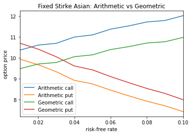

```python
## Vary interest rate for Fixed Strike Asian Options
## Set initial values of parameters
S0=100
K=100
r=[x*0.01 for x in range(1,11)]
sigma=0.2
T=1
t=252

A_fs_call=[]
A_fs_put=[]
G_fs_call=[]
G_fs_put=[]
for ritem in r:
    price_path=geometricpath(ritem,sigma,t,T,S0,100000)
    C_0,P_0=A_asian_option_fs(K,ritem,T,price_path)
    A_fs_call.append(C_0)
    A_fs_put.append(P_0)
    C_1,P_1=G_asian_option_fs(K,ritem,T,price_path)
    G_fs_call.append(C_1)
    G_fs_put.append(P_1)

plt.plot(r,A_fs_call)
plt.plot(r,A_fs_put)
plt.plot(r,G_fs_call)
plt.plot(r,G_fs_put)
plt.xlim(0.01,0.1)
plt.legend(['Arithmetic call','Arithmetic put','Geometric call', 'Geometric put'])
plt.xlabel('risk-free rate')
plt.ylabel('option price')
plt.title('Fixed Stirke Asian: Arithmetic vs Geometric')
plt.show()
```

For call options, option price rises according to the increase of risk-free rate, while for put options it falls according to the increase of risk-free rate.

[figure not shown]

```python
## Vary interest rate for Lookback Options
## Set initial values of parameters
S0=100
K=100
r=[x*0.01 for x in range(1,11)]
sigma=0.2
T=1
t=252

L_fix_call=[]
L_fix_put=[]
L_flt_call=[]
L_flt_put=[]
for ritem in r:
    price_path=geometricpath(ritem,sigma,t,T,S0,100000)
    C_0,P_0=lookback_option_fix(K,ritem,T,price_path)
    L_fix_call.append(C_0)
    L_fix_put.append(P_0)
    C_1,P_1=lookback_option_flt(ritem,T,price_path)
    L_flt_call.append(C_1)
    L_flt_put.append(P_1)

plt.plot(r,A_fs_call)
plt.plot(r,A_fs_put)
plt.plot(r,G_fs_call)
plt.plot(r,G_fs_put)
plt.xlim(0.01,0.1)
plt.legend(['Fixed strike call','Fixed strike put','Floating strike call', 'Floating strike put'])
plt.xlabel('risk-free rate')
plt.ylabel('option price')
plt.title('Lookback options: fixed strike vs floating strike')
plt.show()
```

### Problem

We can observe a strange thing that as risk-free rate increases, option price decreases, which is contradict to the 3-D result.

### Vary initial stock price

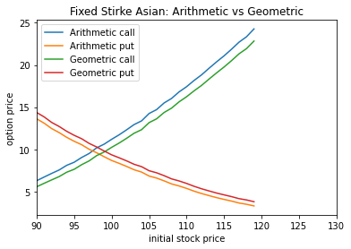

```python
## Vary initial stock price for Fixed Strike Asian Options
## Set initial values of parameters
S0=[90+1*x for x in range(0,30)]
K=100
r=0.05
sigma=0.2
T=1
t=252

A_fs_call=[]
A_fs_put=[]
G_fs_call=[]
G_fs_put=[]
for sitem in S0:
    price_path1=geometricpath(r,sigma,t,T,sitem,100000)
    C_0,P_0=A_asian_option_fs(K,r,T,price_path1)
    A_fs_call.append(C_0)
    A_fs_put.append(P_0)
    C_1,P_1=G_asian_option_fs(K,r,T,price_path1)
    G_fs_call.append(C_1)
    G_fs_put.append(P_1)

plt.plot(S0,A_fs_call)
plt.plot(S0,A_fs_put)
plt.plot(S0,G_fs_call)
plt.plot(S0,G_fs_put)
plt.xlim(90,130)
plt.legend(['Arithmetic call','Arithmetic put','Geometric call', 'Geometric put'])
plt.xlabel('initial stock price')
plt.ylabel('option price')
plt.title('Fixed Stirke Asian: Arithmetic vs Geometric')
plt.show()
```

For call options, option price rises according to the increase of initial stock price, while for put options it falls according to the increase of initial stock price.

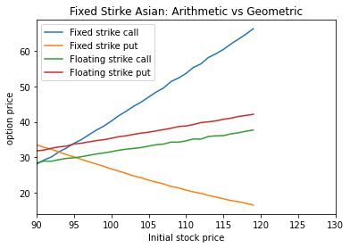

```python
## Vary initial stock price for Lookback Options
## Set initial values of parameters
S0=[90+1*x for x in range(0,30)]
K=100
r=0.05
sigma=0.2
T=1
t=252

L_fix_call=[]
L_fix_put=[]
L_flt_call=[]
L_flt_put=[]
for sitem in S0:
    price_path1=geometricpath(r,sigma,t,T,sitem,100000)
    C_0,P_0=lookback_option_fix(K,r,T,price_path1)
    L_fix_call.append(C_0)
    L_fix_put.append(P_0)
    C_1,P_1=lookback_option_flt(r,T,price_path1)
    L_flt_call.append(C_1)
    L_flt_put.append(P_1)

plt.plot(S0,L_fix_call)
plt.plot(S0,L_fix_put)
plt.plot(S0,L_flt_call)
plt.plot(S0,L_flt_put)
plt.xlim(90,130)
plt.legend(['Fixed strike call','Fixed strike put','Floating strike call', 'Floating strike put'])
plt.xlabel('Initial stock price')
plt.ylabel('option price')
plt.title('Fixed Stirke Asian: Arithmetic vs Geometric')
plt.show()
```

For fixed strike call options, option price rises according to the increase of initial stock price, while for put options it falls according to the increase of initial stock price.

### Problem

For floating strike call and put options, option price rises as initial stock price increases.

## References

https://www.maths.ed.ac.uk/~ateckent/vacation_reports/Summer%20Project%20Final.pdf

https://personal.ntu.edu.sg/nprivault/MA5182/lookback-options.pdf

https://www.math.hkust.edu.hk/~maykwok/courses/MATH6380/Topic3.pdf

http://uu.diva-portal.org/smash/get/diva2:301070/FULLTEXT01.pdf

Paul Wilmott on Quantitative Finance: Volume 1 and 2

CQF python labs